# Final Project R

T-test

```r
t.test(absences ~ G3, df, var.equal = T)
```

```
##
##  Two Sample t-test
##
## data:  absences by G3
## t = 1.1233, df = 393, p-value = 0.262
## alternative hypothesis: true difference in means between group Falied and group Passed is not equal to 0
## 95 percent confidence interval:
##  -0.6796396  2.4913904
## sample estimates:
## mean in group Falied mean in group Passed
##             6.188172             5.282297
```

```r
# calculate the critical value
crit_result <- qt(0.95, 393, lower.tail = T)
print(paste0("Critical Value: ", crit_result))
```

```
## [1] "Critical Value: 1.64874011363683"
```

```r
# out of curiousity I will check the effect siez
coh_effect <- cohensD(absences ~ G3, df, method = "pooled")
print(paste0("Effect: ", coh_effect))
```

```
## [1] "Effect: 0.11322821521104"
```

T-test RESULTS:

- T-est results: t(393)=1.12; p=0.26
- Critical value: 1.65
- Effect: 0.11 (very small)

Based on the information above we can accept H0. Meaning that the mean of absences of the group that failed does not differ from the mean of absences of the group that passed

**Anova: *Medu: Mothers’ Education Level* and *absences***

Visualizing data

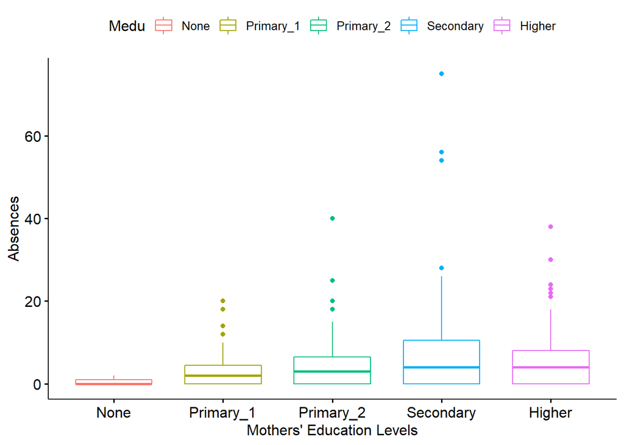

```r
ggboxplot(df, x = "Medu", y = "absences",
          color = "Medu", ylab = "Absences", xlab = "Mothers' Education Levels")
```

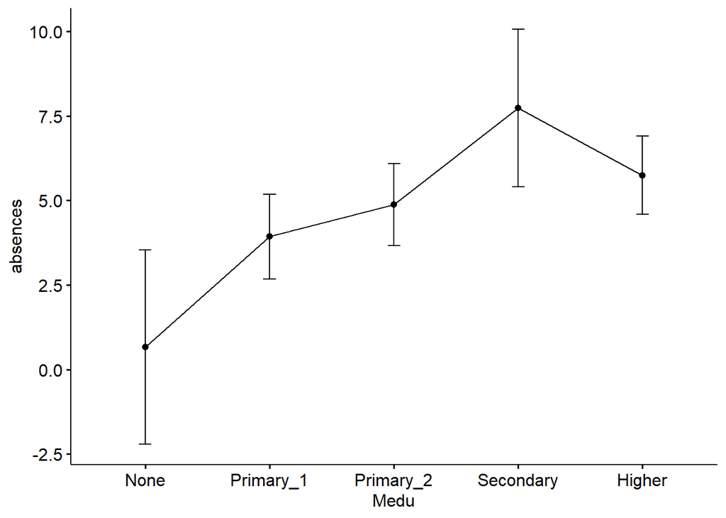

```r
ggline(df, x = "Medu", y = "absences", add = "mean_ci")
```

Performing One-Way ANOVA

```r
anova_ <- aov(absences ~ Medu, df)
summary(anova_)
```

```
##              Df Sum Sq Mean Sq F value Pr(>F)
## Medu          4    742   185.5   2.953   0.02 *
## Residuals   390  24494    62.8
## ---
## Signif. codes:  0 '***' 0.001 '**' 0.01 '*' 0.05 '.' 0.1 ' ' 1
```

Calculating the critical values

```r
qf(0.025, 4, 390, lower.tail = F)
```

```
## [1] 2.818698
```

There are is significant differences between the groups (based on the critical value it’s not that big):

- F (4; 390) = 2.95; p = 0.02
- Critical value: 2.81

Pairwise Comparison (Not Adjusted)

```r
TukeyHSD(anova_)
```

```
##   Tukey multiple comparisons of means
##     95% family-wise confidence level
##
## Fit: aov(formula = absences ~ Medu, data = df)
##
## $Medu
##                           diff        lwr        upr     p adj
## Primary_1-None       3.2655367 -9.5887015 16.1197750 0.9572429
## Primary_2-None       4.2071197 -8.5135749 16.9278143 0.8943782
## Secondary-None       7.0707071 -5.6572586 19.7986727 0.5484587
## Higher-None          5.0814249 -7.6007359 17.7635858 0.8074979
## Primary_2-Primary_1  0.9415830 -2.6045092  4.4876752 0.9499977
## Secondary-Primary_1  3.8051703  0.2330830  7.3772577 0.0302836
## Higher-Primary_1     1.8158882 -1.5893875  5.2211639 0.5882127
## Secondary-Primary_2  2.8635873 -0.1932801  5.9204548 0.0785245
## Higher-Primary_2     0.8743052 -1.9858579  3.7344683 0.9187109
## Higher-Secondary    -1.9892821 -4.8816119  0.9030476 0.3271663
```

Pairwise Comparison (Adjusted)

```r
TukeyHSD(anova_, p.adj = "bonferroni")
```

```
##   Tukey multiple comparisons of means
##     95% family-wise confidence level
##
## Fit: aov(formula = absences ~ Medu, data = df)
##
## $Medu
##                           diff        lwr        upr     p adj
## Primary_1-None       3.2655367 -9.5887015 16.1197750 0.9572429
## Primary_2-None       4.2071197 -8.5135749 16.9278143 0.8943782
## Secondary-None       7.0707071 -5.6572586 19.7986727 0.5484587
## Higher-None          5.0814249 -7.6007359 17.7635858 0.8074979
## Primary_2-Primary_1  0.9415830 -2.6045092  4.4876752 0.9499977
## Secondary-Primary_1  3.8051703  0.2330830  7.3772577 0.0302836
## Higher-Primary_1     1.8158882 -1.5893875  5.2211639 0.5882127
## Secondary-Primary_2  2.8635873 -0.1932801  5.9204548 0.0785245
## Higher-Primary_2     0.8743052 -1.9858579  3.7344683 0.9187109
## Higher-Secondary    -1.9892821 -4.8816119  0.9030476 0.3271663
```

Looks like both, adjusted and not adjusted tests show us that the only significant difference are in between the group that have *Secondary* and *Primary_1* education (p=0.03; p adj=0.03).

Visualization of Post Hoc test

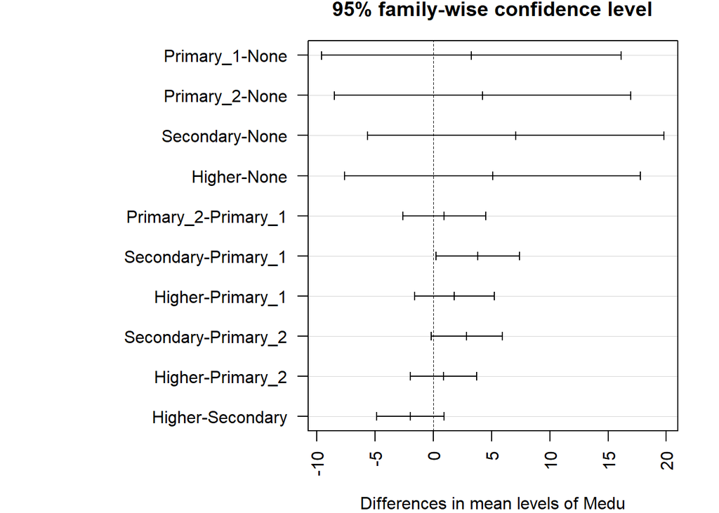

```r
par(mar = c(4, 15, 2, 2))
plot(TukeyHSD(anova_, p.adj = "fdr", conf.level = 0.95), las = 2)
```

Check assumption:

1. Homogeneity of Variance assumption

Plot

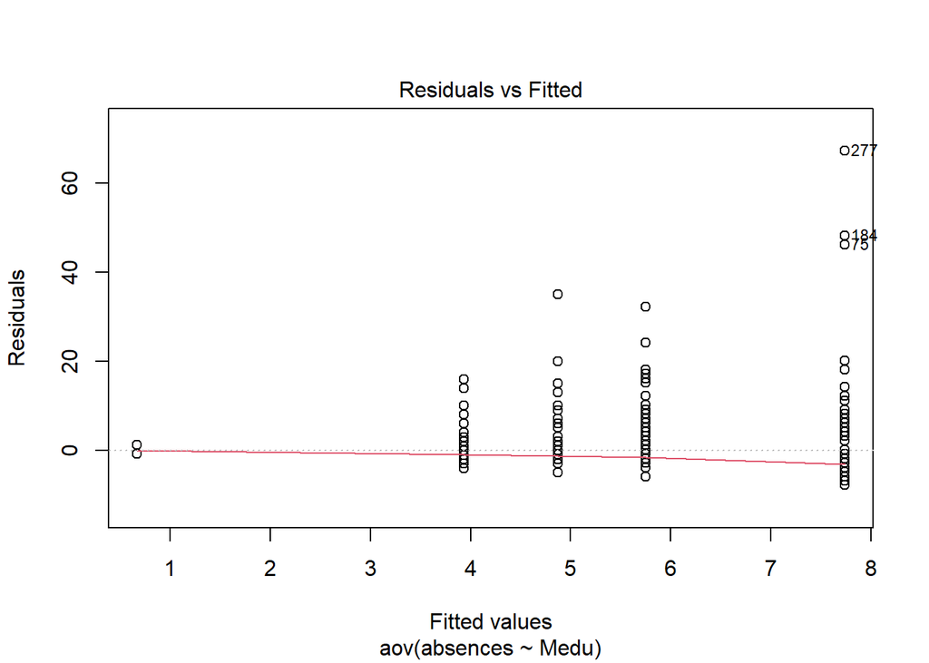

```r
plot(anova_, 1)
```

Looks like there are a few values (277, 184, 75) which can affect normality and homogeneity of variance. Before removing the outliers I will perform Levene’s test as well.

```r
leveneTest(absences ~ Medu, df)
```

```
## Levene's Test for Homogeneity of Variance (center = median)
##        Df F value   Pr(>F)
## group   4  3.5115 0.007844 **
##       390
## ---
## Signif. codes:  0 '***' 0.001 '**' 0.01 '*' 0.05 '.' 0.1 ' ' 1
```

2. Normality assumption

Plot

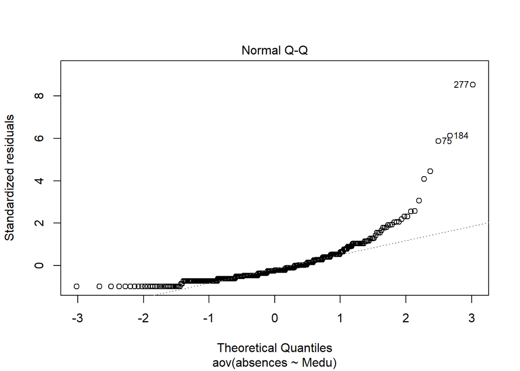

```r
plot(anova_, 2)
```

We can observe a deviation of the points from the line in the right tail.

```r
# get residuals
anova_residuals <- residuals(object = anova_)

# check normality (Shapiro-Wilk test)
shapiro.test(anova_residuals)
```

```
##
##  Shapiro-Wilk normality test
##
## data:  anova_residuals
## W = 0.71592, p-value < 2.2e-16
```

Since the assumptions are not met I will perform a non-parametric test (Kruskal-Wallis rank sum test)

```r
kruskal.test(absences ~ Medu, df)
```

```
##
##  Kruskal-Wallis rank sum test
##
## data:  absences by Medu
## Kruskal-Wallis chi-squared = 7.5884, df = 4, p-value = 0.1079
```

The Kruskal-Wallis rank sum test gives us a p-value of 0.11. Meaning that there are no significant difference in means between the groups.

### MODEL

I will build a couple of models based on the information gatherd above.

I will also try to have a model that has the least number of variables and performs as close as possible to the best model there could be with the choosen variables by a chosen model using the *step-wise backward* methond.

Since *G3* binary I will use *binomial()* as a family function and the link will be *logit* (default)

*$\color{blue}{\text{Model with all the variables}}$*

```r
fit_full <- glm(G3 ~., df, family = binomial())
summary(fit_full)
```

```
##
## Call:
## glm(formula = G3 ~ ., family = binomial(), data = df)
##
## Deviance Residuals:
##     Min       1Q   Median       3Q      Max
## -1.9388  -1.0593   0.5854   1.0007   2.3133
##
## Coefficients:
##                  Estimate Std. Error z value Pr(>|z|)
## (Intercept)      0.482317   2.187126   0.221   0.8255
## famsizeLE3       0.303216   0.259792   1.167   0.2431
## PstatusTogether -0.208091   0.383157  -0.543   0.5871
## MeduPrimary_1   -2.183427   1.520194  -1.436   0.1509
## MeduPrimary_2   -1.997631   1.517459  -1.316   0.1880
## MeduSecondary   -2.028598   1.531629  -1.324   0.1853
## MeduHigher      -1.616968   1.567381  -1.032   0.3022
## FeduPrimary_1   -0.255117   1.467284  -0.174   0.8620
## FeduPrimary_2    0.254625   1.467586   0.173   0.8623
## FeduSecondary   -0.032606   1.470287  -0.022   0.9823
## FeduHigher       0.800281   1.489769   0.537   0.5911
## Mjobhealth       1.062836   0.587168   1.810   0.0703 .
## Mjobother        0.591202   0.374939   1.577   0.1148
## Mjobservices     0.856932   0.412239   2.079   0.0376 *
## Mjobteacher     -0.087887   0.542295  -0.162   0.8713
## Fjobhealth      -0.294611   0.745183  -0.395   0.6926
## Fjobother        0.007021   0.522193   0.013   0.9893
## Fjobservices     0.058345   0.538945   0.108   0.9138
## Fjobteacher      0.083867   0.692012   0.121   0.9035
## guardianmother   0.123916   0.284140   0.436   0.6628
## guardianother   -0.328922   0.470611  -0.699   0.4846
## famsupyes       -0.457615   0.238533  -1.918   0.0551 .
## higheryes        1.171406   0.620621   1.887   0.0591 .
## internetyes      0.349830   0.313023   1.118   0.2637
## DalcLow         -0.420623   0.346006  -1.216   0.2241
## DalcMedium      -0.360857   0.541236  -0.667   0.5049
## DalcHigh        -0.139222   0.823747  -0.169   0.8658
## DalcVery_High    0.903511   0.987409   0.915   0.3602
## WalcLow          0.161070   0.305549   0.527   0.5981
## WalcMedium      -0.195450   0.344735  -0.567   0.5707
## WalcHigh        -0.727568   0.448171  -1.623   0.1045
## WalcVery_High   -0.612708   0.655369  -0.935   0.3498
## absences        -0.009810   0.014734  -0.666   0.5055
## ---
## Signif. codes:  0 '***' 0.001 '**' 0.01 '*' 0.05 '.' 0.1 ' ' 1
##
## (Dispersion parameter for binomial family taken to be 1)
##
##     Null deviance: 546.25  on 394  degrees of freedom
## Residual deviance: 485.26  on 362  degrees of freedom
## AIC: 551.26
##
## Number of Fisher Scoring iterations: 4
```

*$\color{blue}{\text{Model with the variables (Mjob, famsup and higher)}}$*

```r
fit_1 <- glm(G3 ~ Mjob +famsup + higher, df, family = binomial())
summary(fit_1)
```

```
##
## Call:
## glm(formula = G3 ~ Mjob + famsup + higher, family = binomial(),
##     data = df)
##
## Deviance Residuals:
##     Min       1Q   Median       3Q      Max
## -1.6628  -1.1678   0.8571   1.0698   2.1224
##
## Coefficients:
##              Estimate Std. Error z value Pr(>|z|)
## (Intercept)   -1.8600     0.6177  -3.011  0.00260 **
## Mjobhealth     1.4683     0.4726   3.107  0.00189 **
## Mjobother      0.6332     0.3279   1.931  0.05343 .
## Mjobservices   1.0870     0.3473   3.129  0.00175 **
## Mjobteacher    0.6601     0.3866   1.708  0.08773 .
## famsupyes     -0.2812     0.2180  -1.290  0.19718
## higheryes      1.4852     0.5823   2.550  0.01076 *
## ---
## Signif. codes:  0 '***' 0.001 '**' 0.01 '*' 0.05 '.' 0.1 ' ' 1
##
## (Dispersion parameter for binomial family taken to be 1)
##
##     Null deviance: 546.25  on 394  degrees of freedom
## Residual deviance: 521.08  on 388  degrees of freedom
## AIC: 535.08
##
## Number of Fisher Scoring iterations: 4
```

*$\color{blue}{\text{Model with the variables (Mjob and higher)}}$*

```r
fit_2 <- glm(G3 ~ Mjob + higher, df, family = binomial())
summary(fit_2)
```

```
##
## Call:
## glm(formula = G3 ~ Mjob + higher, family = binomial(), data = df)
##
## Deviance Residuals:
##     Min       1Q   Median       3Q      Max
## -1.5645  -1.2224   0.8346   1.1331   2.0462
##
## Coefficients:
##              Estimate Std. Error z value Pr(>|z|)
## (Intercept)   -1.9620     0.6118  -3.207  0.00134 **
## Mjobhealth     1.4162     0.4697   3.015  0.00257 **
## Mjobother      0.6459     0.3270   1.975  0.04828 *
## Mjobservices   1.0647     0.3460   3.077  0.00209 **
## Mjobteacher    0.6314     0.3848   1.641  0.10086
## higheryes      1.4213     0.5786   2.457  0.01402 *
## ---
## Signif. codes:  0 '***' 0.001 '**' 0.01 '*' 0.05 '.' 0.1 ' ' 1
##
## (Dispersion parameter for binomial family taken to be 1)
##
##     Null deviance: 546.25  on 394  degrees of freedom
## Residual deviance: 522.76  on 389  degrees of freedom
## AIC: 534.76
##
## Number of Fisher Scoring iterations: 4
```

**Compering the models**

```r
anova(fit_2, fit_1, fit_full, test = "Chisq")
```

```
## Analysis of Deviance Table
##
## Model 1: G3 ~ Mjob + higher
## Model 2: G3 ~ Mjob + famsup + higher
## Model 3: G3 ~ famsize + Pstatus + Medu + Fedu + Mjob + Fjob + guardian +
##     famsup + higher + internet + Dalc + Walc + absences
##   Resid. Df Resid. Dev Df Deviance Pr(>Chi)
## 1       389     522.76
## 2       388     521.08  1    1.674  0.19576
## 3       362     485.26 26   35.820  0.09504 .
## ---
## Signif. codes:  0 '***' 0.001 '**' 0.01 '*' 0.05 '.' 0.1 ' ' 1
```

Looks like the models’ don’t have a significat difference in performance.

- Model *fit_full*: AIC is 551.26
- Model *fit_1*: AIC is 535.08
- Model *fit_2*: AIC is 534.76

*$\color{blue}{\text{Model step-wise backward}}$*

```r
fit_stepwise <- step(fit_full, direction = "backward")
```

```
## Start:  AIC=551.26
## G3 ~ famsize + Pstatus + Medu + Fedu + Mjob + Fjob + guardian +
##     famsup + higher + internet + Dalc + Walc + absences
##
##            Df Deviance    AIC
## - Fjob      4   485.65 543.65
## - Dalc      4   488.47 546.47
## - Medu      4   488.87 546.87
## - Walc      4   489.63 547.63
## - guardian  2   486.48 548.48
## - Pstatus   1   485.56 549.56
## - absences  1   485.72 549.72
## - internet  1   486.52 550.52
## - famsize   1   486.64 550.64
## - Fedu      4   492.84 550.84
## <none>          485.26 551.26
## - famsup    1   489.00 553.00
## - higher    1   489.37 553.37
## - Mjob      4   496.14 554.14
##
## Step:  AIC=543.65
## G3 ~ famsize + Pstatus + Medu + Fedu + Mjob + guardian + famsup +
##     higher + internet + Dalc + Walc + absences
##
##            Df Deviance    AIC
## - Dalc      4   488.92 538.92
## - Medu      4   489.41 539.41
## - Walc      4   490.27 540.27
## - guardian  2   486.87 540.87
## - Pstatus   1   485.92 541.92
## - absences  1   486.13 542.13
## - famsize   1   486.95 542.95
## - internet  1   487.04 543.04
## <none>          485.65 543.65
## - Fedu      4   494.06 544.06
## - famsup    1   489.65 545.65
## - higher    1   489.67 545.67
## - Mjob      4   496.41 546.41
##
## Step:  AIC=538.92
```

[output cut: 85 more lines]

```
## - famsup    1   500.85 530.85
## - higher    1   501.45 531.45
## - Mjob      4   508.04 532.04
## - Fedu      4   510.14 534.14
##
## Step:  AIC=527.88
## G3 ~ Fedu + Mjob + famsup + higher + Walc
##
##          Df Deviance    AIC
## <none>        497.88 527.88
## - Walc    4   507.38 529.38
## - famsup  1   502.05 530.05
## - higher  1   502.91 530.91
## - Mjob    4   511.37 533.37
## - Fedu    4   511.72 533.72
```

Checking the best model

```r
summary(fit_stepwise)
```

```
##
## Call:
## glm(formula = G3 ~ Fedu + Mjob + famsup + higher + Walc, family = binomial(),
##     data = df)
##
## Deviance Residuals:
##     Min       1Q   Median       3Q      Max
## -1.8844  -1.0621   0.6644   1.0332   2.1898
##
## Coefficients:
##               Estimate Std. Error z value Pr(>|z|)
## (Intercept)   -1.53984    1.57303  -0.979  0.32763
## FeduPrimary_1 -0.29692    1.45328  -0.204  0.83811
## FeduPrimary_2  0.33979    1.44373   0.235  0.81393
## FeduSecondary  0.07911    1.44181   0.055  0.95624
## FeduHigher     0.94185    1.44525   0.652  0.51461
## Mjobhealth     1.40827    0.49204   2.862  0.00421 **
## Mjobother      0.68341    0.34087   2.005  0.04497 *
## Mjobservices   1.03733    0.36103   2.873  0.00406 **
## Mjobteacher    0.37126    0.41711   0.890  0.37342
## famsupyes     -0.46562    0.22997  -2.025  0.04290 *
## higheryes      1.24531    0.59971   2.077  0.03785 *
## WalcLow        0.06763    0.29216   0.231  0.81695
## WalcMedium    -0.37945    0.29556  -1.284  0.19920
## WalcHigh      -0.93223    0.35282  -2.642  0.00824 **
## WalcVery_High -0.45157    0.44656  -1.011  0.31191
## ---
## Signif. codes:  0 '***' 0.001 '**' 0.01 '*' 0.05 '.' 0.1 ' ' 1
##
## (Dispersion parameter for binomial family taken to be 1)
##
##     Null deviance: 546.25  on 394  degrees of freedom
## Residual deviance: 497.88  on 380  degrees of freedom
## AIC: 527.88
##
## Number of Fisher Scoring iterations: 4
```

```r
fit_stepwise$call
```

```
## glm(formula = G3 ~ Fedu + Mjob + famsup + higher + Walc, family = binomial(),
##     data = df)
```

```r
fit_final <- glm(formula = G3 ~ Fedu + Mjob + famsup + higher + Walc, family = binomial(), data = df)

summary(fit_final)
```

```
##
## Call:
## glm(formula = G3 ~ Fedu + Mjob + famsup + higher + Walc, family = binomial(),
##     data = df)
##
## Deviance Residuals:
##     Min       1Q   Median       3Q      Max
## -1.8844  -1.0621   0.6644   1.0332   2.1898
##
## Coefficients:
##               Estimate Std. Error z value Pr(>|z|)
## (Intercept)   -1.53984    1.57303  -0.979  0.32763
## FeduPrimary_1 -0.29692    1.45328  -0.204  0.83811
## FeduPrimary_2  0.33979    1.44373   0.235  0.81393
## FeduSecondary  0.07911    1.44181   0.055  0.95624
## FeduHigher     0.94185    1.44525   0.652  0.51461
## Mjobhealth     1.40827    0.49204   2.862  0.00421 **
## Mjobother      0.68341    0.34087   2.005  0.04497 *
## Mjobservices   1.03733    0.36103   2.873  0.00406 **
## Mjobteacher    0.37126    0.41711   0.890  0.37342
## famsupyes     -0.46562    0.22997  -2.025  0.04290 *
## higheryes      1.24531    0.59971   2.077  0.03785 *
## WalcLow        0.06763    0.29216   0.231  0.81695
## WalcMedium    -0.37945    0.29556  -1.284  0.19920
## WalcHigh      -0.93223    0.35282  -2.642  0.00824 **
## WalcVery_High -0.45157    0.44656  -1.011  0.31191
## ---
## Signif. codes:  0 '***' 0.001 '**' 0.01 '*' 0.05 '.' 0.1 ' ' 1
##
## (Dispersion parameter for binomial family taken to be 1)
##
##     Null deviance: 546.25  on 394  degrees of freedom
## Residual deviance: 497.88  on 380  degrees of freedom
## AIC: 527.88
##
## Number of Fisher Scoring iterations: 4
```

Comparing models *fit_2* and *fit_final*

```r
anova(fit_2, fit_final, test = "Chisq")
```

```
## Analysis of Deviance Table
##
## Model 1: G3 ~ Mjob + higher
## Model 2: G3 ~ Fedu + Mjob + famsup + higher + Walc
##   Resid. Df Resid. Dev Df Deviance Pr(>Chi)
## 1       389     522.76
## 2       380     497.88  9    24.88 0.003107 **
## ---
## Signif. codes:  0 '***' 0.001 '**' 0.01 '*' 0.05 '.' 0.1 ' ' 1
```

Based on the chi-squared p-value (0.003) model *fit_final* with the variables (“Fedu”, “Mjob”, “famsup” + higher“,”Walc“) fits better than the model *fit_2* with the variables (”Mjob" and “higher”)

- Model *fit_final*: AIC is 527.88
- Model *fit_2*: AIC is 534.76

As shown above the difference in between the AICs’ is very small but *fit_fianl* has 5 variables versus *fit_2* has 2 variables.

I have decided to go on with the model *fit_2* because it has fewer variables.

#### *Model Parameters*

```r
exp(coef(fit_2))
```

```
##  (Intercept)   Mjobhealth    Mjobother Mjobservices  Mjobteacher    higheryes
##    0.1405738    4.1213091    1.9076408    2.8999624    1.8801606    4.1425883
```

- The odds of passing with a positive grade are higher for studernts that want to get a higher education.
- The odds of passing with a positive grade is higher if the mothers’ job is in heath, services, teaching or other.

#### *Checking for overdispersion*

There are 2 ways to check for overdispersion:

**1st method**

If the ratio is a lot larger than 1, than we can assume that there is an overdispersion issue

```r
deviance(fit_2)/df.residual(fit_2)
```

```
## [1] 1.343848
```

We got a result of *1.34* which is slightly higher than 1, meaning that there is a very small chance that we have the issue with overdispersion.

**2nd method**

Check if there is a significant difference between 2 models, *binomial()* and *quacibinomial()*

Building a model with the argument *family = quasibinomial()*

```r
fit_2_quasi <- glm(G3 ~ Mjob + higher, df, family = quasibinomial())
```

```r
pchisq(summary(fit_2_quasi)$dispersion * fit_2$df.residual, fit_2$df.residual, lower = F)
```

```
## [1] 0.3410127
```

With a p-values of 0.34 (not significant) can conclude that the model doesn’t have an overdispersion issue.